# ESM 244 Homework 3

Hanna Buechi

3/3/2019

### Task 1: Open science perspectives

Open science aims to benefit both scientists and society. These benefits include transparency and reproducibility to verify findings, and access to more potential collaborators, access to data and manuscripts without paywalls. These are all excellent because they have the potential to make the process of science more accessible to scientists without traditional, university-based resources; and make it more legitimate and rigorous. But I have heard less from my peers about the benefits that open science can bring to *society*, which I think is a critical conversation to have.

As I have come-of-age as a scientist, it has become clear that the scientific establishment has never been particularly great at communicating effectively and clearly with the general public. There are cultural barriers, resource barriers, ideological barriers, educational barriers - all kinds of hurdles that have to be overcome to solve the problem. But sometimes I have this frustrated, angry thought: “Why haven’t we figured this out yet?!” Why haven’t scientists figured out how to communicate and share their knowledge in a way that gains trust and sparks excitement?

Bahlai et al. (2019) brought up a great point that non-scientists “fund [often through taxes], participate in, benefit from, and in some cases are the subjects of [scientific] research.” But often, they are shut out of the process. Open science can help with this. While I doubt that even a decent *minority* of the public would access openly-available data or manuscripts, some would, and those people may feel more empowered as a result.

I have personal experience with this. I worked as a research in a molecular evolutionary biology lab and our work on a rather controversial topic was profiled in *The New York Times*. After the publication, my lab manager received hundreds of emails from *NYT* readers. A few stuck in my mind; they specifically asked for more information about our study and cited themselves as taxpayers whose money funds NSF grants like ours. They were mostly confrontational and alluded to a lack of belief in evolution, but nonetheless, they got me thinking. Sharing data, methods, and manuscripts (beyond press releases and science journalism) with the public in a fairly digestible way could go a long way in building faith. Many people still would not have the tools (including internet, which I had not thought of as a barrier until reading these articles! Such an interesting dilemma…) or the desire to “look under the hood” so to speak, but I think that people would recognize that effort to share.

That lab that was profiled in the *NYT* did not practice open science. The principal investigator, while established in his field, was incredibly competitive. The next evolutionary biology lab I worked in did, though. We pre-printed manuscripts in repositories like bioRxiv and posted free PDFs of all of our publications on our lab website. This was a formative experience for me because that PI was an early-career researcher. He existed on the continuum of open science - he wasn’t “entirely open.” We did not make all of our data publicly available. He learned the tools when he had the time. But he wanted to institute open habits early on in his career so that they became the norm.

He was also a cis, straight, white male from a prestigious academic background in the United States - arguably some of the characteristics that make it the easiest to take advantage of open science. It can be enough of a battle for scientists who are POC, non-male, non-white, disabled, primary caretakers, etc. to establish themselves and gain career stability. The nobility of open science, when discussed without practical suggestions for implementation and risks, still creates a social strata with winners and losers. The winners are those who can afford the risks and pat themselves on the back for a job well done. The losers are everyone else. This is not fair.

In my group project at Bren, we have had many conversations about what it means for our team to be open and transparent. We had to sign a non-disclosure agreement with our client in order to access our primary dataset. Given my previous experiences with being pretty open, this has been hard to accept. It just feels weird that we cannot share most of our data. Our collaborators have wanted access, too, but we cannot grant that. That has lead to some very awkward conversations and the unraveling of one relationship. We want to share this with our peers and whoever else might want to see it. Right now, a major hurdle for me is the thought of dealing with criticism of our methods and conclusions - this makes me very nervous. But it is an excellent opportunity to make me a better scientist, which is what open science is about for me.

```r
library(tidyverse)
library(tseries)
library(forecast)
library(plm)
library(Ecdat)
library(lmtest)
library(car)
library(effsize)
library(pwr)
library(plyr)
library(sf)
library(tmap)
library(leaflet)
library(ggrepel)
library(ggspatial)
library(RColorBrewer)
library(raster)
library(ggrepel)

truckee <- read_csv("truckee_flow.csv")
lizard <- read_csv("lter_lizard_pitfall.csv")

## Truckee River data

# mean_va -> mean monthly discharge in cubic feet per second
# year and month are self-explanatory

## Lizard data

# Zone: vegetation zone (C=creosote bush, G=grassland, M=mesquite, P=playa, T=tarbush)
# Site: Site location (CALI GRAV SAND; BASN IBPE SUMM; RABB NORT WELL; COLL SMAL TOBO; EAST TAYL WEST)
# Plot: Plot A, B, C, D
# Pit: Pit number (1 -16)
# Spp: Species code (CNTI, UTST, CNTE, CNIN, SCUN, HOMA, EUOB) # check more of these
# Sex: M (male), F (female), J (juvenile)
# Rcap: Recaptured  (N=new capture, R = recapture)
# Toenum: Toe mark number (includes Tail Mark beginning 3/16/95)
# SV-L: Snout-vent length in mm
# Total-length: Total length in mm
# Weight: Body weight in grams
# Tail: Tail condition (B = broken, W = whole)
# PC: Problem code (1 = see history log; 0 = no problem)
```

### Task 2: Truckee River flow (2000 - 2016)

#### Part a: Decomposed time series graphs

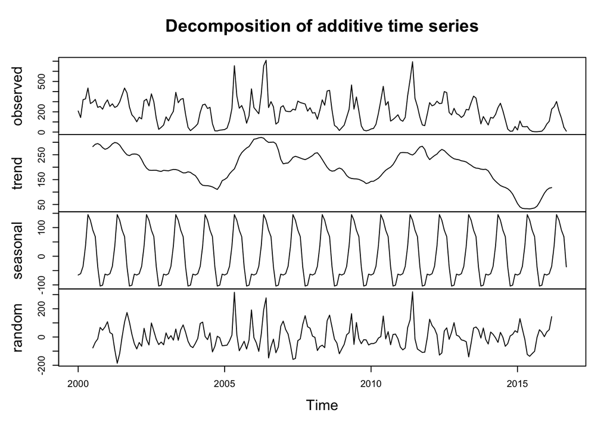

```r
# I did some data clean up in Excel because it was quick and easy

# create a vector of time series-specific data # the original df doesn't work with tseries()

mean_ts <- ts(truckee$mean_va, frequency = 12, start = c(2000,1)) # frequency = 12 indicates that this is monthly data that starts in 2000

# mean_ts # look at it to confirm that everything worked - yes, it ends in September 2016

# plot(mean_ts) # plot to explore the trend, seasonality, cycle

# a little bit of a downward trend
# seasonality: the annual, intermediate peaks
# cyclical: the big peaks are repeated twice

mean_dc <- decompose(mean_ts) # does Steps 1-4 of decomposition (Detect trend, de-trend by subtraction, calculate average seasonal component (ASC), "random/remainder" is cycle)

plot(mean_dc) # original, trend, seasonality, residuals that show trends that don't depend on the other decompositions
```

```r
# flat lines for seasonality and cycle would indicate no contribution to time series variation/pattern
# I'm interested in those peaks in 2006/2007 and 2012 - where does the variation come from?
# They are still seen in trend, not seen in seasonality, still seen in cycle -> attribute to cycle
# seasonality is strong (scale is 1/6 of scale of observed) and very regular
# cycle peaks/troughs are very similar to observed data
```

#### Part b: Holt-Winters or ARIMA for forecasting

Holt-Winters exponential smoothing coefficients:

```r
mean_hw <- HoltWinters(mean_ts)

# alpha = 0.2418713, beta = 0, gamma = 0.3384547
# coefficients will be used in linear combinations for forecasting

# mean_plot <- plot(mean_hw) # looks pretty good with original data
```

Holt-Winters forecasting, 5 years into the future:

```r
mean_forecast <- forecast(mean_hw, h = 60) # 60 months = 5 years into the future - remember, we defined this as monthly data using the tserie() package
# forecast_plot <- plot(mean_forecast)

# SEASONALITY is dominating, we don't get much input from the past cyclical peaks, probably because HW weight recent observations

# dark grey ribbons 80% CI, light grey 95% CI
```

#### Part c: Check Holt-Winters residuals:

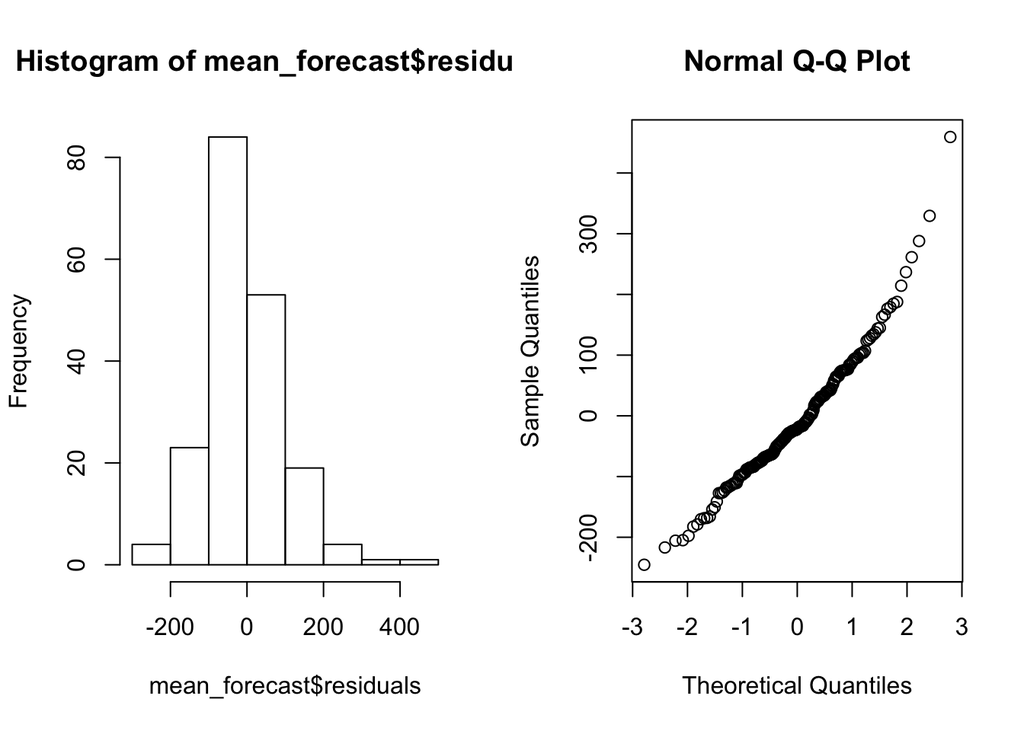

```r
par(mfrow = c(1,2))
hist(mean_forecast$residuals)
qqnorm(mean_forecast$residuals)
```

```r
# Residuals look normally distributed
```

#### Extra: ARIMA for comparison

```r
mean_pdq <- auto.arima(mean_ts)
mean_pdq

# p,d,q non-seasonal: (2,1,1); seasonal (0,0,2)

# fit the model

mean_arima <- arima(mean_ts, order = c(2,1,1), seasonal = list(order = c(0,0,2)))
mean_arima

# Check out the residuals: they look normally distributed

# par(mfrow = c(1,2))
# hist(mean_arima$residuals)
# qqnorm(mean_arima$residuals)
```

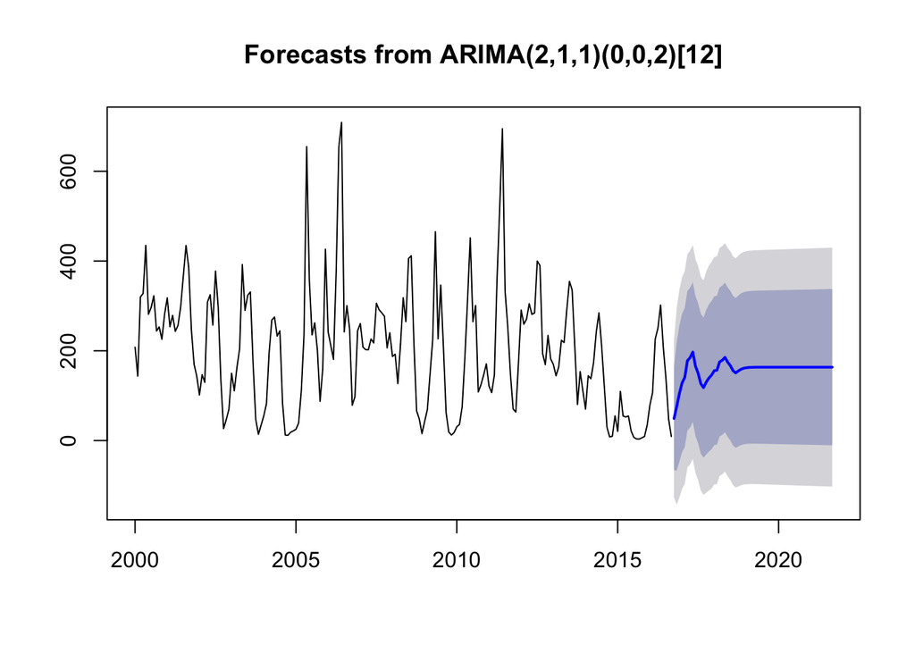

```r
# forecast

forecast_mean <- forecast(mean_arima, h = 60) # 60 time periods / months = 5 years
plot(forecast_mean)
```

```r
# This doesn't look good...
```

### Task 3: Mapping California’s National Parks

```r
# Remember: .shp - geometries, .dbf - attributes, .prj - projections --> if there is no projection associated, we'll have to set one

ca_counties <- read_sf(".", layer = "california_county_shape_file") # "." indicates current working directory
st_crs(ca_counties) = 4326 # transform projection system to WGS84
parks <- read_sf(".", layer = "nps_boundary" ) # I imagine I'll have to clip this to California
st_crs(parks) = 4326 # st_crs(parks) to confirm

# Clip National Parks data by California Counties data
parks_clip <- st_intersection(parks, ca_counties) %>%
  filter(UNIT_TYPE == "National Park") %>%
  dplyr::rename(Park = UNIT_NAME)

parks_clip <- parks_clip %>%
  mutate(PARKNAME = ifelse(is.na(parks_clip$PARKNAME), "Redwood", parks_clip$PARKNAME))
```

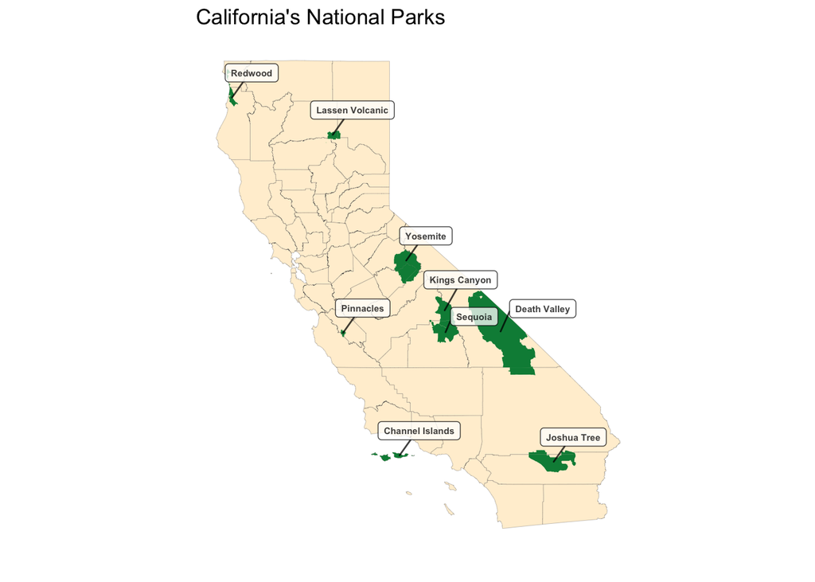

```r
# counties to be background, parks to be foreground: code for ecoregions (analogous to parks_clip) and dams from Lab 6 will be helpful

parks_coords <- parks_clip %>%
  st_centroid %>% # find polygon centroids (sf points object)
  st_coordinates # extract the coordinates of these points as a matrix

# insert centroid long and lat fields as attributes of polygons
parks_clip$long <- parks_coords[,1] # base R syntax for first column, which is X aka. longitude
parks_clip$lat <- parks_coords[,2]

# separate df for labeling, only the one entry for each park - do this manually, unfortunately
# Matt gave me an easier way: DON'T clip the nps_boundary to ca_counties because that makes the separate park/county polygons. Instead, keep them separate and filter nps_boundary by state (California) and map as a separate layer. Thanks, Matt! Example code saved in Github.

parks_label <- parks_clip %>%
  slice(c(2,3,8,11,17,14,15,22,23))

ggplot(parks_clip) +
  geom_sf(data = ca_counties, # add the county borders
          fill = "papayawhip",
          color = "gray 30",
          size = 0.05)+
  geom_sf(fill = "springgreen4",
          color = "NA", # no borders around the polygons
          show.legend = FALSE) + # gets rid of legend
  ggtitle("California's National Parks") +
  coord_sf(datum = NA) +
  geom_label_repel(data=parks_label,
                  aes(long, lat, label = PARKNAME),
                  alpha = 0.75, size = 2,
                  fontface = "bold",
                  min.segment.length = unit(0, 'lines'),
                  nudge_x = 0.5,
                  nudge_y = 0.5) +
  labs(x = " ", y = " ") +
  theme_minimal()
```

### Task 4: Lizards in the Northern Chihuahan Desert - Data Wrangling and Analysis

```r
weight <- lizard %>%
  filter(site == "CALI") %>%
  filter(sex == "M" | sex == "F") %>%
  filter(weight > 0) %>%
  filter(toe_num > 0)

tail <- lizard %>%
  filter(site == "CALI") %>%
  filter(sex == "M" | sex == "F") %>%
  filter(tail == "B" | tail == "W")

# panel regression because some individuals are sampled multiple times - I know this based on toe number
# however, this is not a balanced panel

# other variables that might explain weight: total_length, SV_length, tail

# data is our time variable

# What is the effect of sex on lizard weight?

weight_panel <- weight %>%
  select(date, sex, total_length, SV_length, tail, weight, toe_num)

weight_panel$date <- as.Date(weight_panel$date, "%m/%d/%y")
weight_panel$sex <- as.factor(weight_panel$sex)
weight_panel$total_length <- as.numeric(weight_panel$total_length)
weight_panel$SV_length <- as.numeric(weight_panel$SV_length)
weight_panel$toe_num <- as.numeric(weight_panel$toe_num)
weight_panel$tail <- as.factor(weight_panel$tail)

# kept getting an error that there was a duplicate entry for date and toe number - it's toe number 4 - this could have been a data entry mistake, I think that one of those duplicates should have been a male lizard - interesting that toe-number can be repeated between Male and Female!

# Index by sex too: now error because also toe_number 1: same date, same sex, same toe_number

weight_panel <- weight_panel %>%
  filter(toe_num != 4) %>%
  filter(toe_num != 1)

# weight_model <- plm(weight ~ sex + total_length + tail,
                  #data = weight_panel,
                  #index = c("date","toe_num", "sex"),
                  #model = "within") # entity fixed effects model

# this still isn't working, time to move on
```

#### Part 1. For all lizards trapped at site ‘CALI’, do weights of male and female adult lizards differ significantly?

##### Mann-Whitney U Test (distributions aren’t normal)

```r
# Lab 4 from ESM 206 for reference

## Data wrangling: separate df for sexes, make sure there aren't "." for weight, filter out recaptured animals so that they aren't counted twice (I'm hoping that toe_num isn't a unique identifier and that the dates are relevant...)
male <- lizard %>%
  filter(site == "CALI" | sex == "M") %>%
  filter(weight > 0) %>%
  dplyr::select(weight, rcap, tail) %>%
  filter(rcap != "R")

female <- lizard %>%
  filter(site == "CALI", sex == "F") %>%
  filter(weight > 0) %>%
  dplyr::select(weight, rcap, tail) %>%
  filter(rcap != "R")

male$weight <- as.numeric(male$weight)
female$weight <- as.numeric(female$weight)

## Vector of weights
m <- male$weight
f <- female$weight

## Check sample sizes: they are very different!!
length(m) # 840
length(f) # 61

## Check for normality: neither histograms indicate normality (makes sense, can't have weights below 0) and Q-Q plots don't follow a 45-deg line --> non-parametric test
# par(mfrow = c(2, 2)) # two columns, two rows
# hist(m)
# qqnorm(m)
# hist(f)
# qqnorm(f)

## Test for equal variances: Null hypothesis is that variances are equal --> yes, p = 0.28
f_test <- var.test(m, f)
f_test

MWU <- wilcox.test(m,f)
MWU

## Parametric t-test: same conclustion to non-parametric test
# t_test_diff <- t.test(m, f, var.equal = TRUE)
# t_test_diff
```

#### Part 2. For lizards trapped at the ‘CALI’ site, is there a significant difference in the proportion of adult male and female lizards with broken tails?

##### Chi-square test

```r
# Lab 6 from ESM 206 for reference

male_tail <- male %>%
  dplyr::select(tail) %>%
  filter(tail == "B" | tail == "W")

female_tail <- female %>%
  dplyr::select(tail) %>%
  filter(tail == "B" | tail == "W")

# How many of each sex have whole or broken tails?

as.data.frame(table(female_tail$tail)) # 48, 13
as.data.frame(table(male_tail$tail)) # 638, 198

# Make a contingency table

ff <- c(48,13)
mm <- c(638,198)

tail_status <- rbind(ff, mm)
colnames(tail_status) <- c("Whole", "Broken")

tail_prop_table <- prop.table(tail_status, margin = 1) # calculate probabilities by row

# Null hypothesis: proportions of broken vs. whole tail are the same within each sex

tail_chi <- chisq.test(tail_status)
tail_chi
```

There is no significant difference in the proportion of males and females with broken tails that were captured at the “CALI” sampling site ($\chi$^2(1) = 0.070, p = 0.79, $\alpha$ = 0.05). For both sexes, about 75% had whole, unbroken tails.